# seattle-airbnb-analysis

- Introduction
- 1.Business Understanding
- 2.Data Understanding
  - 2.1 Explore Airbnb Seattle Datasets
    - 2.1.1 Explore Calendar Dataset
      - 2.1.1.1 Missing Values
      - 2.1.1.2 Unique Values
    - 2.1.2 Explore Listings Dataset
      - 2.1.1.1 Missing Listing Values
      - 2.1.1.2 Unique Listing Values
- 3.Data Preparation
  - Distribution of listing prices by neighborhoods
- 4.Modeling
- 5.Results and Evaluation
- 6.Modeling with additional features
- 7.Conclusion

# Introduction

This notebook follows the CRISP-DM process to analyze the Seattle AirBnb Open Data on Kaggle (https://www.kaggle.com/airbnb/seattle/data).

- Business Understanding • Understanding project objectives and requirements; Data mining problem definition
- Data Understanding • Initial data collection and familiarization; Identify data quality issues; Initial, obvious results
- Data Preparation • Record and attribute selection; Data cleansing
- Modeling • Run the data mining tools
- Evaluation • Determine if results meet business needs
- Deployment • Put the resulting models into practice; Set up for continuous mining of the data

## 1.Business Understanding

Airbnb Inc, is an American online marketplace and hospitality service brokerage company based in San Francisco, California, United States. Members can use the service to arrange or offer lodging, primarily homestays, or tourism experiences.

The booking price of the properties vary according various attributes like its location, property type, size, number of rooms, amenities, day of the week and month of the year etc. Airbnb made its dataset about property listings in Seattle in 2016 publicly available on Kaggle.

Our goal is to study this dataset to understand the major trends in the pricing over the year and across the neighbourhoods in Seattle. We also want to understand through statistical modelling about how the attributes related to the property might be influencing the booking price on Airbnb.

These are the 5 guiding questions for our analysis:

- Q1. Distribution of listing prices by neighborhoods?
- Q2. How does the price of listings vary through out the year. This would help us understand what are the busy months for rentals in Seattle.
- Q3. How does availability vary through out the year? Are more listings available during busy months?
- Q4. What property attributes have a high influence on price
- Q5. How well can we predict listing price?

## 2.Data Understanding

We are provided with 3 datasets by Kaggle

- Listings, including full descriptions and average review score
- Reviews, including unique id for each reviewer and detailed comments
- Calendar, including listing id and the price and availability for that day

In this step we will try to understand these datasets in sufficient detail to help us answer the questions mentioned in step 1.

### 2.1 Explore Airbnb Seattle Datasets

```python
import numpy as np
import pandas as pd
import os
import re
import matplotlib.pyplot as plt
import seaborn as sns
import plotly.offline as pyo
import plotly.graph_objs as go

from sklearn.linear_model import LinearRegression
from sklearn.model_selection import train_test_split
from sklearn.metrics import r2_score, mean_squared_error
```

```python
%matplotlib inline
```

```python
datadir_location='/Users/gangireddyl/Downloads/seattle_airbnb' #modify path to a location on your local directory
```

```python
os.listdir(datadir_location)
```

```
['reviews.csv',
 '.DS_Store',
 'reviews.csv.zip',
 'listings.csv',
 'calendar.csv',
 'calendar.csv.zip',
 'listings.csv.zip']
```

```python
revcsv  = os.path.join(datadir_location, 'reviews.csv')
listcsv = os.path.join(datadir_location, 'listings.csv')
calcsv  = os.path.join(datadir_location, 'calendar.csv')
```

```python
df_cal =  pd.read_csv(calcsv)
df_rev =  pd.read_csv(revcsv)
df_list = pd.read_csv(listcsv)
```

```python
df_cal.shape , df_rev.shape, df_list.shape
```

```
((1393570, 4), (84849, 6), (3818, 92))
```

```python
print ("listing has {} no. of rows and {} no. of columns".format(df_list.shape[0], df_list.shape[1] ))
print ("calender has {} no. of rows and {} no. of columns".format(df_cal.shape[0], df_cal.shape[1] ))
print ("reviews has {} no. of rows and {} no. of columns".format(df_rev.shape[0], df_rev.shape[1] ))
```

```
listing has 3818 no. of rows and 92 no. of columns
calender has 1393570 no. of rows and 4 no. of columns
reviews has 84849 no. of rows and 6 no. of columns
```

- listings has the maximum number of columns i.e. 92
- Calendar dataset has the maximum number of rows
- Let us set the display options fo pandas so all columns are displayed.

```python
pd.set_option('display.max_columns', 100)
pd.set_option('display.max_rows', 100)
```

#### 2.1.1 Explore Calendar Dataset

```python
df_cal.head()
```

|  | listing_id | date | available | price |
| --- | --- | --- | --- | --- |
| 0 | 241032 | 2016-01-04 | t | $85.00 |
| 1 | 241032 | 2016-01-05 | t | $85.00 |
| 2 | 241032 | 2016-01-06 | f | NaN |
| 3 | 241032 | 2016-01-07 | f | NaN |
| 4 | 241032 | 2016-01-08 | f | NaN |

##### 2.1.1.1 Missing Values

```python
df_cal.isnull().mean()
```

```
listing_id    0.00000
date          0.00000
available     0.00000
price         0.32939
dtype: float64
```

```python
df_cal.info()
```

```
<class 'pandas.core.frame.DataFrame'>
RangeIndex: 1393570 entries, 0 to 1393569
Data columns (total 4 columns):
 #   Column      Non-Null Count    Dtype
---  ------      --------------    -----
 0   listing_id  1393570 non-null  int64
 1   date        1393570 non-null  object
 2   available   1393570 non-null  object
 3   price       934542 non-null   object
dtypes: int64(1), object(3)
memory usage: 42.5+ MB
```

- price is listed as type object

```python
len(df_cal.listing_id.unique())
```

```
3818
```

```python
df_cal.available.unique()
```

```
array(['t', 'f'], dtype=object)
```

##### 2.1.2.2 Unique Values

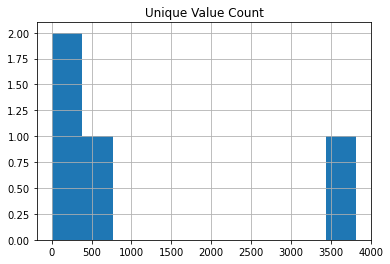

```python
pd.DataFrame((df_cal.T.apply(lambda x: x.nunique(), axis=1)), columns=['Unique Value Count']).hist();
```

```python
pd.DataFrame((df_cal.T.apply(lambda x: x.nunique(), axis=1)), columns=['Unique Value Count'])
```

|  | Unique Value Count |
| --- | --- |
| listing_id | 3818 |
| date | 365 |
| available | 2 |
| price | 669 |

- price is not always populated. Rest of the fields always have values
- 3818 unique listings are available which exactly match with the rows in listing dataset

#### Formating 'price' column:

- 'Price' is central to answer some of our questions, it has some null values...
- But it has a dolar sign and therefore it is represented as string object.
- Inorder to proceed further the '$' sign will have to be removed and dtype of 'price' coumn will be changed to float.

```python
df_cal['price'] = df_cal['price'].str.replace("[$, ]", "", regex=True).astype("float")
df_cal['price'].head()
```

```
0    85.0
1    85.0
2     NaN
3     NaN
4     NaN
Name: price, dtype: float64
```

#### 2.1.2 Explore Listings Dataset

```python
df_list.head()
```

|  | id | listing_url | scrape_id | last_scraped | name | summary | space | description | experiences_offered | neighborhood_overview | notes | transit | thumbnail_url | medium_url | picture_url | xl_picture_url | host_id | host_url | host_name | host_since | host_location | host_about | host_response_time | host_response_rate | host_acceptance_rate | host_is_superhost | host_thumbnail_url | host_picture_url | host_neighbourhood | … |
| --- | --- | --- | --- | --- | --- | --- | --- | --- | --- | --- | --- | --- | --- | --- | --- | --- | --- | --- | --- | --- | --- | --- | --- | --- | --- | --- | --- | --- | --- | --- |
| 0 | 241032 | https://www.airbnb.com/rooms/241032 | 20160104002432 | 2016-01-04 | Stylish Queen Anne Apartment | NaN | Make your self at home in this charming one-be... | Make your self at home in this charming one-be... | none | NaN | NaN | NaN | NaN | NaN | https://a1.muscache.com/ac/pictures/67560560/c... | NaN | 956883 | https://www.airbnb.com/users/show/956883 | Maija | 2011-08-11 | Seattle, Washington, United States | I am an artist, interior designer, and run a s... | within a few hours | 96% | 100% | f | https://a0.muscache.com/ac/users/956883/profil... | https://a0.muscache.com/ac/users/956883/profil... | Queen Anne | … |
| 1 | 953595 | https://www.airbnb.com/rooms/953595 | 20160104002432 | 2016-01-04 | Bright & Airy Queen Anne Apartment | Chemically sensitive? We've removed the irrita... | Beautiful, hypoallergenic apartment in an extr... | Chemically sensitive? We've removed the irrita... | none | Queen Anne is a wonderful, truly functional vi... | What's up with the free pillows? Our home was... | Convenient bus stops are just down the block, ... | https://a0.muscache.com/ac/pictures/14409893/f... | https://a0.muscache.com/im/pictures/14409893/f... | https://a0.muscache.com/ac/pictures/14409893/f... | https://a0.muscache.com/ac/pictures/14409893/f... | 5177328 | https://www.airbnb.com/users/show/5177328 | Andrea | 2013-02-21 | Seattle, Washington, United States | Living east coast/left coast/overseas. Time i... | within an hour | 98% | 100% | t | https://a0.muscache.com/ac/users/5177328/profi... | https://a0.muscache.com/ac/users/5177328/profi... | Queen Anne | … |
| 2 | 3308979 | https://www.airbnb.com/rooms/3308979 | 20160104002432 | 2016-01-04 | New Modern House-Amazing water view | New modern house built in 2013. Spectacular s... | Our house is modern, light and fresh with a wa... | New modern house built in 2013. Spectacular s... | none | Upper Queen Anne is a charming neighborhood fu... | Our house is located just 5 short blocks to To... | A bus stop is just 2 blocks away. Easy bus a... | NaN | NaN | https://a2.muscache.com/ac/pictures/b4324e0f-a... | NaN | 16708587 | https://www.airbnb.com/users/show/16708587 | Jill | 2014-06-12 | Seattle, Washington, United States | i love living in Seattle. i grew up in the mi... | within a few hours | 67% | 100% | f | https://a1.muscache.com/ac/users/16708587/prof... | https://a1.muscache.com/ac/users/16708587/prof... | Queen Anne | … |
| 3 | 7421966 | https://www.airbnb.com/rooms/7421966 | 20160104002432 | 2016-01-04 | Queen Anne Chateau | A charming apartment that sits atop Queen Anne... | NaN | A charming apartment that sits atop Queen Anne... | none | NaN | NaN | NaN | NaN | NaN | https://a0.muscache.com/ac/pictures/94146944/6... | NaN | 9851441 | https://www.airbnb.com/users/show/9851441 | Emily | 2013-11-06 | Seattle, Washington, United States | NaN | NaN | NaN | NaN | f | https://a2.muscache.com/ac/users/9851441/profi... | https://a2.muscache.com/ac/users/9851441/profi... | Queen Anne | … |
| 4 | 278830 | https://www.airbnb.com/rooms/278830 | 20160104002432 | 2016-01-04 | Charming craftsman 3 bdm house | Cozy family craftman house in beautiful neighb... | Cozy family craftman house in beautiful neighb... | Cozy family craftman house in beautiful neighb... | none | We are in the beautiful neighborhood of Queen ... | Belltown | The nearest public transit bus (D Line) is 2 b... | NaN | NaN | https://a1.muscache.com/ac/pictures/6120468/b0... | NaN | 1452570 | https://www.airbnb.com/users/show/1452570 | Emily | 2011-11-29 | Seattle, Washington, United States | Hi, I live in Seattle, Washington but I'm orig... | within an hour | 100% | NaN | f | https://a0.muscache.com/ac/users/1452570/profi... | https://a0.muscache.com/ac/users/1452570/profi... | Queen Anne | … |

##### 2.1.2.1 Missing Listing Values

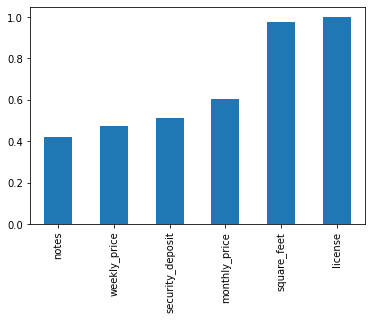

```python
#a look at columns with most missing values
missing = df_list.isnull().mean()
missing = missing[missing > 0.40]
missing.sort_values(inplace=True)
missing.plot.bar()
plt.figure(figsize=(300,250));
```

- We can drop the columns license and square_feet as they are mostly NULL
- Also the columns notes and security_deposit are not useful to answer our questions and can be dropped
- Let us prepare a list of columns that can be dropped based on what we have seen so far

```python
dropped_cols_list = ['listing_url',  'scrape_id','last_scraped', 'name','summary','space','description','experiences_offered','notes','transit','thumbnail_url','medium_url','picture_url','xl_picture_url','host_url','host_location', 'host_about','host_thumbnail_url','host_has_profile_pic', 'street', 'market','smart_location','country_code','country','latitude','longitude','square_feet','license','jurisdiction_names','require_guest_profile_picture']
```

```python
df_list.drop(dropped_cols_list,axis=1,inplace=True)
```

```python
# Inorder to perform merge we will have to rename id to listing_id in listing df: We would then be able to merge listings and calendar datasets
df_list.rename(columns={'id':'listing_id'}, inplace=True)
```

##### 2.1.2.2 Unique Listing Values

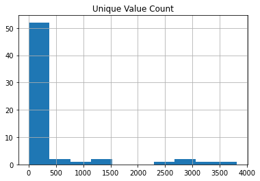

```python
pd.DataFrame((df_list.T.apply(lambda x: x.nunique(), axis=1)), columns=['Unique Value Count']).hist();
```

- Most columns have a limited of unique values but there appear to be a few columns that have a unique value for almost every row.
- These are probably the id , host_id , neighbourhood_overview fields

```python
pd.DataFrame((df_list.T.apply(lambda x: x.nunique(), axis=1)), columns=['Unique Value Count'])
```

|  | Unique Value Count |
| --- | --- |
| listing_id | 3818 |
| neighborhood_overview | 2506 |
| host_id | 2751 |
| host_name | 1466 |
| host_since | 1380 |
| host_response_time | 4 |
| host_response_rate | 45 |
| host_acceptance_rate | 2 |
| host_is_superhost | 2 |
| host_picture_url | 2743 |
| host_neighbourhood | 102 |
| host_listings_count | 27 |
| host_total_listings_count | 27 |
| host_verifications | 116 |
| host_identity_verified | 2 |
| neighbourhood | 81 |
| neighbourhood_cleansed | 87 |
| neighbourhood_group_cleansed | 17 |
| city | 7 |
| state | 2 |
| zipcode | 28 |
| is_location_exact | 2 |
| property_type | 16 |
| room_type | 3 |
| accommodates | 15 |
| bathrooms | 12 |
| bedrooms | 8 |
| beds | 11 |
| bed_type | 5 |
| amenities | 3284 |
| price | 273 |
| weekly_price | 395 |
| monthly_price | 356 |
| security_deposit | 46 |
| cleaning_fee | 118 |
| guests_included | 15 |
| extra_people | 45 |
| minimum_nights | 22 |
| maximum_nights | 68 |
| calendar_updated | 34 |
| has_availability | 1 |
| availability_30 | 31 |
| availability_60 | 61 |
| availability_90 | 91 |
| availability_365 | 363 |
| calendar_last_scraped | 1 |
| number_of_reviews | 195 |
| first_review | 984 |
| last_review | 321 |
| review_scores_rating | 42 |
| review_scores_accuracy | 7 |
| review_scores_cleanliness | 8 |
| review_scores_checkin | 8 |
| review_scores_communication | 8 |
| review_scores_location | 6 |
| review_scores_value | 8 |
| requires_license | 1 |
| instant_bookable | 2 |
| cancellation_policy | 3 |
| require_guest_phone_verification | 2 |
| calculated_host_listings_count | 18 |
| reviews_per_month | 654 |

```python
df_list[['price','weekly_price','monthly_price']].head()
```

|  | price | weekly_price | monthly_price |
| --- | --- | --- | --- |
| 0 | $85.00 | NaN | NaN |
| 1 | $150.00 | $1,000.00 | $3,000.00 |
| 2 | $975.00 | NaN | NaN |
| 3 | $100.00 | $650.00 | $2,300.00 |
| 4 | $450.00 | NaN | NaN |

#### Format price, weekly and monthly price

```python
df_list['price'] = df_list['price'].str.replace("[$, ]", "", regex=True).astype("float")
df_list['price'].head()
```

```
0     85.0
1    150.0
2    975.0
3    100.0
4    450.0
Name: price, dtype: float64
```

```python
### weekly_price and monthly_price also have '$' and are defined as dtype object.
```

```python
df_list['weekly_price'] = df_list['weekly_price'].str.replace("[$, ]", "", regex=True).astype("float")
df_list['monthly_price'] = df_list['monthly_price'].str.replace("[$, ]", "", regex=True).astype("float")
```

## 3.Data Preparation

### Q1. Distribution of listing prices by neighborhoods?

```python
neighbourhood_list = df_list['neighbourhood_cleansed'].unique().tolist()
hist_data = []

for neighbourhood in neighbourhood_list:
    trace = go.Histogram(x = df_list.loc[df_list['neighbourhood_cleansed'] == neighbourhood].price.tolist(), opacity=0.75, name = neighbourhood)
    hist_data.append(trace)

hist_layout = go.Layout(barmode='stack', xaxis = dict(title='Listing Price'), yaxis = dict(title='Count'))
hist_fig = go.Figure(data=hist_data, layout=hist_layout)

hist_fig.show()
```

[interactive chart not shown]

```python
neighborhood_mean_df = pd.DataFrame(df_list.groupby('neighbourhood_cleansed').mean()['price'].sort_values(ascending=False))
neighborhood_mean_df = neighborhood_mean_df.rename(columns = {'price': 'mean_price'})

neighborhood_std_df = pd.DataFrame(df_list.groupby('neighbourhood_cleansed').std()['price'].sort_values(ascending=False))
neighborhood_std_df = neighborhood_std_df.rename(columns = {'price': 'std_price'})

neighborhood_df = neighborhood_mean_df.merge(neighborhood_std_df, on='neighbourhood_cleansed')

top_15 = neighborhood_df.index[:15].tolist() # the subset of neighborhoods we'll analyze

neighborhood_df.head(15)
```

| neighbourhood_cleansed | mean_price | std_price |
| --- | --- | --- |
| Southeast Magnolia | 231.705882 | 225.117682 |
| Portage Bay | 227.857143 | 197.523458 |
| Westlake | 194.470588 | 173.057475 |
| West Queen Anne | 187.769231 | 170.476425 |
| Montlake | 182.789474 | 171.700508 |
| Briarcliff | 176.571429 | 96.767536 |
| Sunset Hill | 176.055556 | 149.680630 |
| Industrial District | 173.333333 | 104.769588 |
| Alki | 171.619048 | 97.471685 |
| Windermere | 169.900000 | 104.919493 |
| Pioneer Square | 169.260870 | 81.552112 |
| Central Business District | 164.213592 | 68.148001 |
| Fauntleroy | 164.100000 | 131.965863 |
| Belltown | 162.893162 | 110.523031 |
| East Queen Anne | 159.414634 | 114.311784 |

```python
neighborhood_df.tail()
```

| neighbourhood_cleansed | mean_price | std_price |
| --- | --- | --- |
| North Delridge | 76.375000 | 26.881760 |
| Georgetown | 76.125000 | 15.994977 |
| South Delridge | 74.666667 | 31.804326 |
| Olympic Hills | 71.687500 | 48.098120 |
| Rainier Beach | 68.555556 | 33.465034 |

```python
box_data = []

for neighbourhood in top_15:
    trace = go.Box(x = df_list.loc[df_list['neighbourhood_cleansed'] == neighbourhood].price.tolist(), name = neighbourhood)
    box_data.append(trace)

box_layout = go.Layout(xaxis = dict(title='Listing Price'))
box_fig = go.Figure(data=box_data, layout=box_layout)

box_fig.show()
```

[interactive chart not shown]